# Exploratory Data Analysis

Description: Dataset is provided by DeltaX which is a part of assignment for Data Analyst Role. This Dataset comprises of Ad permorformance of Google Adword dated between 1st Aug, 2020 - 28th Feb,2021.

here are following things to keep in mind:

- One Campaign can have one or more Ad Groups. One Ad group can have one or more ads. In the given dataset - we have only 1 campaign; 4 Ad Groups and multiple ads.
- Assume Adgroup 1, 2, 3 & 4 are targeting different audiences
- Think of Ad1 & Ad2 as two concepts being tried across 4 Adgroups (audiences)

###### While performing EDA (exploratory data analysis) / building dashboards please primarily focus on the Efficiency Metrics and use the Raw Metrics as indicative.

##### Raw metrics:

Impressions - Number of times the ad was shown

- Clicks - Number of times the ad clicked shown
- Cost - Amount spent to show ad
- Conversions - Number of transactions received (higher the better)
- Revenue - Total value of transactions received (higher the better)

##### Efficiency metrics:

Needs to be calculated and are based on raw metrics

- CTR - Clicks / Impression (higher the better - used to evaluate if the users find the ad relevant)
- CPC - Cost / Click (lower the better - used to evaluate if the cost for getting a click)
- CPA - Cost / Conversion (lower the better - used to evaluate if the cost for getting a conversion)
- ROI - Revenue/Cost (higher the better - used to evaluate the effectiveness of the advertising budget spent)

```python
#importing the required libraries

import pandas as pd
import numpy as np


import matplotlib
import plotly.graph_objs as go
import plotly.offline as py
from plotly.offline import init_notebook_mode, iplot, download_plotlyjs
import plotly.graph_objs as go
import matplotlib.pyplot as plt
import seaborn as sns
%matplotlib inline

import warnings
warnings.filterwarnings('ignore')
```

```python
#import the dataset into jupyter notebook
df = pd.read_csv('C:/Users/playo/Desktop/DeltaX DA/data.csv')
```

## Understand the Given Data

```python
#Read the Data
df.head(10)
```

|  | date | campaign | adgroup | ad | impressions | clicks | cost | conversions | revenue |
| --- | --- | --- | --- | --- | --- | --- | --- | --- | --- |
| 0 | 01-08-2020 | campaign 1 | adgroup 1 | ad 1 | 24 | 6 | 0.08 | 0 | 0.00 |
| 1 | 01-08-2020 | campaign 1 | adgroup 2 | ad 1 | 1 | 0 | 0.00 | 0 | 0.00 |
| 2 | 01-08-2020 | campaign 1 | adgroup 3 | ad 1 | 13 | 4 | 0.04 | 0 | 0.00 |
| 3 | 01-08-2020 | campaign 1 | adgroup 4 | ad 1 | 5 | 4 | 0.08 | 0 | 0.00 |
| 4 | 01-08-2020 | campaign 1 | adgroup 1 | ad 2 | 247 | 126 | 1.29 | 4 | 925.71 |
| 5 | 01-08-2020 | campaign 1 | adgroup 2 | ad 2 | 7 | 2 | 0.04 | 0 | 0.00 |
| 6 | 01-08-2020 | campaign 1 | adgroup 4 | ad 2 | 6 | 3 | 0.05 | 0 | 0.00 |
| 7 | 01-08-2020 | campaign 1 | adgroup 1 | ad 3 | 129 | 52 | 0.58 | 0 | 0.00 |
| 8 | 01-08-2020 | campaign 1 | adgroup 3 | ad 3 | 104 | 56 | 0.56 | 0 | 0.00 |
| 9 | 01-08-2020 | campaign 1 | adgroup 4 | ad 3 | 6 | 5 | 0.05 | 0 | 0.00 |

```python
df.shape
```

```
(4571, 9)
```

### Cleaning and Data Preperation

[figure not shown]

```python
#lets start with checking null values in the dataset
df.isna().sum()
```

```
date           0
campaign       0
adgroup        0
ad             0
impressions    0
clicks         0
cost           0
conversions    0
revenue        0
dtype: int64
```

```python
df['adgroup'].value_counts()
```

```
adgroup 3    1672
adgroup 1    1314
adgroup 4     858
adgroup 2     727
Name: adgroup, dtype: int64
```

```python
df.nunique()
```

```
date            212
campaign          1
adgroup           4
ad               70
impressions     571
clicks          355
cost            810
conversions      49
revenue        1223
dtype: int64
```

```python
#convert categorical variable to interger with Label Encoder
from sklearn.preprocessing import LabelEncoder
labelEnc = LabelEncoder()


df['adgroup'] = labelEnc.fit_transform(df['adgroup'])

df["impressions"] = np.log(df["impressions"])
df["clicks"] = np.log(df["clicks"])
df["cost"] = np.log(df["cost"])
```

```python
#Build a new feature for Efficiency metrics, as they are not in the dataset

df['CTR'] = df['clicks']/df['impressions']
df['CPC'] = df['cost']/df['clicks']
df['CPA'] = df['cost']/df['conversions']
df['ROI'] = df['revenue']/df['cost']

df['CPC'].fillna(df.CPC.interpolate(),inplace=True)
df['CPA'].fillna(df.CPA.interpolate(),inplace=True)

#replacing the NaN and Negative Values.
df.replace([-np.inf], 0, inplace=True)
df.replace([np.inf,np.NaN], 100,inplace=True)
```

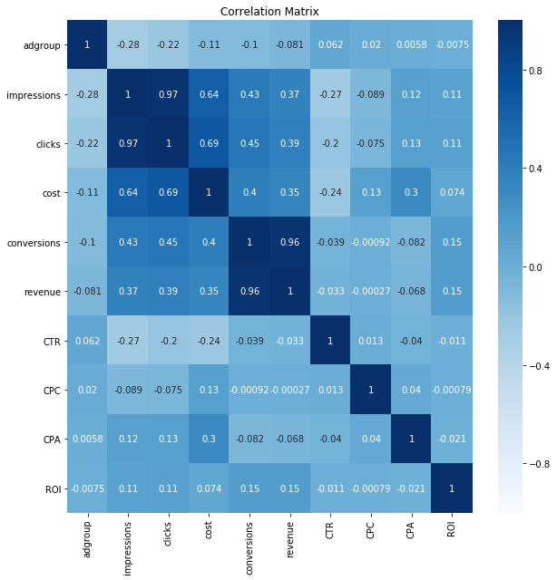

```python
fig1 = plt.figure(figsize = (10,10));
plt.title('Correlation Matrix')
df.corr()
sns.heatmap(df.corr(), vmin = -1, vmax = 1, cmap = 'Blues', annot=True);
```

```python
df['date']=pd.to_datetime(df['date'])
```

```python
#split date into yyyy,mm,dd columns
df['year'] = df['date'].dt.year
df['month'] = df['date'].dt.month
df['day'] = df['date'].dt.day
```

```python
df.head()
```

|  | date | campaign | adgroup | ad | impressions | clicks | cost | conversions | revenue | CTR | CPC | CPA | ROI | year | month | day |
| --- | --- | --- | --- | --- | --- | --- | --- | --- | --- | --- | --- | --- | --- | --- | --- | --- |
| 0 | 2020-01-08 | campaign 1 | 0 | ad 1 | 3.178054 | 1.791759 | -2.525729 | 0 | 0.00 | 0.563791 | -1.409636 | 0.000000 | -0.000000 | 2020 | 1 | 8 |
| 1 | 2020-01-08 | campaign 1 | 1 | ad 1 | 0.000000 | 0.000000 | 0.000000 | 0 | 0.00 | 0.000000 | -1.865782 | 0.000000 | -0.000000 | 2020 | 1 | 8 |
| 2 | 2020-01-08 | campaign 1 | 2 | ad 1 | 2.564949 | 1.386294 | -3.218876 | 0 | 0.00 | 0.540476 | -2.321928 | 0.000000 | -0.000000 | 2020 | 1 | 8 |
| 3 | 2020-01-08 | campaign 1 | 3 | ad 1 | 1.609438 | 1.386294 | -2.525729 | 0 | 0.00 | 0.861353 | -1.821928 | 0.000000 | -0.000000 | 2020 | 1 | 8 |
| 4 | 2020-01-08 | campaign 1 | 0 | ad 2 | 5.509388 | 4.836282 | 0.254642 | 4 | 925.71 | 0.877826 | 0.052652 | 0.063661 | 3635.335907 | 2020 | 1 | 8 |

```python
print(df)
```

```
           date    campaign  adgroup     ad  impressions    clicks      cost  \
0    2020-01-08  campaign 1        0   ad 1     3.178054  1.791759 -2.525729
1    2020-01-08  campaign 1        1   ad 1     0.000000  0.000000  0.000000
2    2020-01-08  campaign 1        2   ad 1     2.564949  1.386294 -3.218876
3    2020-01-08  campaign 1        3   ad 1     1.609438  1.386294 -2.525729
4    2020-01-08  campaign 1        0   ad 2     5.509388  4.836282  0.254642
5    2020-01-08  campaign 1        1   ad 2     1.945910  0.693147 -3.218876
6    2020-01-08  campaign 1        3   ad 2     1.791759  1.098612 -2.995732
7    2020-01-08  campaign 1        0   ad 3     4.859812  3.951244 -0.544727
8    2020-01-08  campaign 1        2   ad 3     4.644391  4.025352 -0.579818
9    2020-01-08  campaign 1        3   ad 3     1.791759  1.609438 -2.995732
10   2020-01-08  campaign 1        1   ad 3     1.386294  0.000000  0.000000
11   2020-01-08  campaign 1        2   ad 4     3.663562  2.772589 -1.514128
12   2020-01-08  campaign 1        2   ad 5     2.833213  1.791759 -2.813411
13   2020-01-08  campaign 1        2   ad 6     5.533389  4.852030  0.277632
```

[output cut: 175 more lines]

```python
df.info()
```

```
<class 'pandas.core.frame.DataFrame'>
RangeIndex: 4571 entries, 0 to 4570
Data columns (total 16 columns):
date           4571 non-null datetime64[ns]
campaign       4571 non-null object
adgroup        4571 non-null int64
ad             4571 non-null object
impressions    4571 non-null float64
clicks         4571 non-null float64
cost           4571 non-null float64
conversions    4571 non-null int64
revenue        4571 non-null float64
CTR            4571 non-null float64
CPC            4571 non-null float64
CPA            4571 non-null float64
ROI            4571 non-null float64
year           4571 non-null int64
month          4571 non-null int64
day            4571 non-null int64
dtypes: datetime64[ns](1), float64(8), int64(5), object(2)
memory usage: 571.5+ KB
```

```python
min_revenue=df.revenue.min()
max_revenue=df.revenue.max()
ave_revenue=df.revenue.mean()
print('minimum revenue is {}, maximum revenue is {} and average is {} in this dataset between Aug 2020-Feb 2021'.format(min_revenue,max_revenue,ave_revenue))
```

```
minimum revenue is 0.0, maximum revenue is 20515.41 and average is 231.86534018814268 in this dataset between Aug 2020-Feb 2021
```

## Data Visualisation

```python
#creating a piechart of Adgroup
temp = df['adgroup'].value_counts()
chart = [go.Pie(labels = temp.index, values = temp.values)]
py.iplot(chart)
```

[interactive chart not shown]

```python
#Clicks vs impressions starting from ( Jan 1 2017to July 30 2017)

df['clicks'] = df['clicks'].fillna(0).astype('int32')
df['impressions'] = df['impressions'].fillna(0).astype('int32')
df['conversions'] = df['conversions'].fillna(0).astype('int32')
df['revenue'] = df['revenue'].fillna(0).astype('int32')


clicks = df.groupby('month')['clicks'].apply(lambda x:x[x >= 1].count()).reset_index()
impressions = df.groupby('month')['impressions'].apply(lambda x:x[x >= 1].count()).reset_index()
conversions = df.groupby('month')['conversions'].apply(lambda x:x[x >= 1].count()).reset_index()
revenue = df.groupby('month')['revenue'].apply(lambda x:x[x >= 1].count()).reset_index()


clicks = go.Scatter(x = clicks['month'],y= clicks['clicks'], name = 'Clicks',marker=dict(color = "blue"))

impressions = go.Scatter(x = impressions['month'],y= impressions['impressions'],name = 'Impressions',marker=dict(color = "red"))

conversions = go.Scatter(x = conversions['month'],y= conversions['conversions'], name = 'conversions',marker=dict(color = "green"))

py.iplot([clicks,impressions,conversions])
```

[interactive chart not shown]

```python
#revenue by year and months
pd.crosstab(df['year'],
            df['month'],
            values=df['revenue'],
            aggfunc='sum').style.background_gradient(cmap='viridis')
```

| month year | 1 | 2 | 3 | 4 | 5 | 6 | 7 | 8 | 9 | 10 | 11 | 12 |
| --- | --- | --- | --- | --- | --- | --- | --- | --- | --- | --- | --- | --- |
| 2020 | 19137 | 16759 | 18072 | 18897 | 17539 | 19204 | 22331 | 170019 | 155981 | 143636 | 229986 | 67062 |
| 2021 | 51345 | 64531 | 5167 | 2657 | 3518 | 5280 | 3404 | 3869 | 3357 | 4115 | 3625 | 9831 |

```python
#Return on Investment by year and months
pd.crosstab(df['year'],
            df['month'],
            values=df['ROI'],
            aggfunc='sum').style.background_gradient(cmap='viridis')
```

| month year | 1 | 2 | 3 | 4 | 5 | 6 | 7 | 8 | 9 | 10 | 11 | 12 |
| --- | --- | --- | --- | --- | --- | --- | --- | --- | --- | --- | --- | --- |
| 2020 | 7264.46 | 49846.3 | 20475 | 19385.6 | 3925.32 | 3494.01 | 13801.6 | 286714 | 64687.5 | 3664.23 | 115861 | 89019.9 |
| 2021 | 32564.7 | 108829 | 19503.4 | 168.055 | -2916.25 | -348.08 | 14803.6 | -41320.7 | 5764.11 | 1347.6 | 26942.7 | 4242.52 |

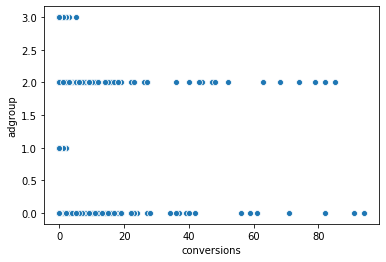

```python
sns.scatterplot(df['conversions'],df['adgroup'])
```

```python
import plotly.express as px
```

```python
px.histogram(df, x="ad", marginal="box", title='Performance of Ads', nbins=20)
```

[interactive chart not shown]

[output not shown]

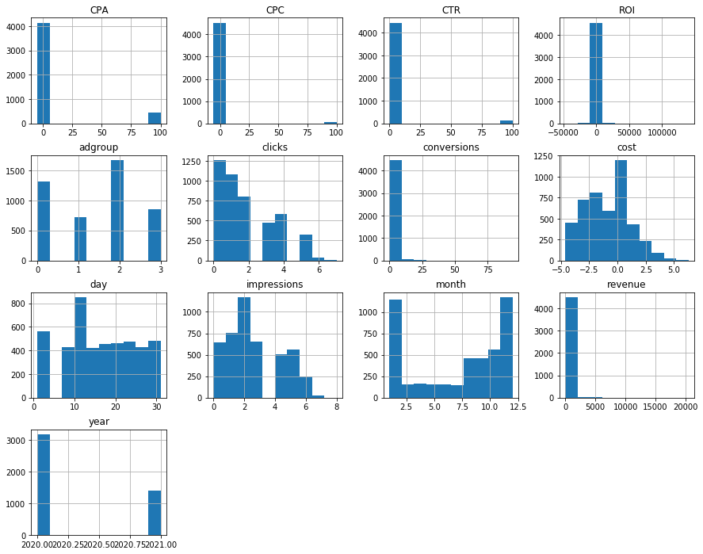

```python
df.hist(figsize=(15,12))
```

## Predictive Modelling

- Here We will convert, train*test* split, the model with Decision Tree and RandomForest and check the accuracy of our model for this dataset.

```python
from sklearn.model_selection import train_test_split
from sklearn import preprocessing
from sklearn.preprocessing import LabelEncoder
from sklearn.linear_model import LinearRegression
from sklearn import metrics
from sklearn import tree
from sklearn.metrics import confusion_matrix
from sklearn.tree import DecisionTreeClassifier
```

```python
#building a model

features = ['adgroup', 'impressions', 'clicks', 'cost',
            'conversions','CTR','CPC','CPA','ROI','month','day']

# Features
X = df[features]

# Target variable
y = df.revenue
```

```python
df = df.drop(['campaign'], axis=1)
```

```python
#building a model

features = ['adgroup', 'impressions', 'clicks', 'cost',
            'conversions','revenue','month','day']

# Features
X = df[features]

# Target variable
y = df.conversions
```

```python
#split the data into training set
X_train,X_test,y_train,y_test = train_test_split(X,y,test_size=0.3)
```

```python
print(X_train.shape)
```

```
(3199, 8)
```

```python
#Decision Tree Classifier Object
classifier = DecisionTreeClassifier()

classifier = classifier.fit(X_train,y_train)
```

```python
#Predict for test dataset
y_predict = classifier.predict(X_test)
```

```python
from sklearn.metrics import accuracy_score
```

```python
#check the accurary of our model
accuracy = accuracy_score(y_predict,y_test)
```

```python
print(accuracy)
```

```
0.9883381924198251
```

```python
#lets Check it with Random Forest for better accuracy
from sklearn.ensemble import RandomForestClassifier
classifier = RandomForestClassifier()
```

```python
classifier.fit(X_train,y_train)
y_predict = classifier.predict(X_test)
```

```python
accuracy = accuracy_score(y_predict,y_test)
```

```python
print(accuracy)
```

```
0.9518950437317785
```

```python
print(confusion_matrix(y_test,y_predict))
```

```
[[947   0   0 ...   0   0   0]
 [  2 160   0 ...   0   0   0]
 [  0   0  75 ...   0   0   0]
 ...
 [  0   0   0 ...   0   0   0]
 [  0   0   0 ...   1   0   0]
 [  0   0   0 ...   0   1   0]]
```

```python
#importing the classification report
from sklearn.metrics import classification_report
```

```python
print(classification_report(y_test,y_predict))
```

```
              precision    recall  f1-score   support

           0       1.00      1.00      1.00       947
           1       1.00      0.99      0.99       162
           2       0.97      1.00      0.99        75
           3       0.86      0.95      0.90        40
           4       0.81      0.81      0.81        27
           5       0.95      0.75      0.84        28
           6       0.69      0.86      0.76        28
           7       0.64      0.53      0.58        17
           8       0.44      0.50      0.47         8
           9       0.44      0.44      0.44         9
          10       0.33      0.17      0.22         6
          12       0.00      0.00      0.00         1
          13       0.00      0.00      0.00         3
```

[output cut: 26 more lines]

[figure not shown]

- References
- Numpy Documentation:https://numpy.org/devdocs/user/quickstart.html
- Matplotlib gallery: https://matplotlib.org/3.1.1/gallery/index.html
- plotly tutorials :https://youtu.be/GGL6U0k8WYA
- DecisionTree & Random Forest Model: https://www.kaggle.com/startupsci/titanic-data-science-solutions
- Analysis Concept: https://www.kaggle.com/akhil14shukla/predicting-revenue